# Homework Titanic Neural Network

Janaar Harbour

11/26/2020

### Importing the data

```r
rm(list = ls())


TitanicTrain <- read.csv("/Users/janaarharbour/Desktop/MSDS 5213 - Predictive Analytics/Assignment 5/tit-train-f.csv", stringsAsFactors = FALSE, na.strings = c("NA",""))

TitanicTest <- read.csv("/Users/janaarharbour/Desktop/MSDS 5213 - Predictive Analytics/Assignment 5/tit-test-f.csv", stringsAsFactors = FALSE, na.strings = c("NA",""))
```

```r
#preProcess(TitanicTrain[,3:12], method = c("center", "scale"))
#names(TitanicTrain)
```

```r
#preProcess(TitanicTest[,2:11], method = c("center", "scale"))
#names(TitanicTest)
```

The dataset “TitanicTest” is missing the **Survived** feature. So I will merge both sets after inserting and filling the missing feature with NA’s.

```r
colSums(is.na(TitanicTrain))
```

```
## PassengerId    Survived      Pclass         Sex         Age       SibSp
##           0           0           0           0           0           0
##       Parch      Ticket        Fare       Cabin    Embarked        name
##           0           0           0           0           0           0
##       title
##           0
```

```r
colSums(is.na(TitanicTest))
```

```
## PassengerId      Pclass         Sex         Age       SibSp       Parch
##           0           0           0           0           0           0
##      Ticket        Fare       Cabin    Embarked        name       title
##           0           0           0           0           0           0
```

```r
TitanicTest$Survived = "NA"
```

To assist with splitting the full dataset later, I am adding an additional variable Set to both datasets filled, respectively, with “Train” or “Test”.

```r
TitanicTrain$Set <- "Train"
TitanicTest$Set <- "Test"
TitanicFull <- rbind(TitanicTrain, TitanicTest)
str(TitanicFull)
```

```
## 'data.frame':    1309 obs. of  14 variables:
##  $ PassengerId: int  1 2 3 4 5 6 7 8 9 10 ...
##  $ Survived   : chr  "NO" "YES" "YES" "YES" ...
##  $ Pclass     : int  3 1 3 1 3 3 1 3 3 2 ...
##  $ Sex        : int  1 0 0 0 1 1 1 1 0 0 ...
##  $ Age        : num  22 38 26 35 35 0 54 2 27 14 ...
##  $ SibSp      : int  1 1 0 1 0 0 0 3 0 1 ...
##  $ Parch      : int  0 0 0 0 0 0 0 1 2 0 ...
##  $ Ticket     : int  21171 17599 3101282 113803 373450 330877 17463 349909 347742 237736 ...
##  $ Fare       : num  7.25 71.28 7.92 53.1 8.05 ...
##  $ Cabin      : int  0 1 0 1 0 0 1 0 0 0 ...
##  $ Embarked   : int  2 1 2 2 2 3 2 2 2 1 ...
##  $ name       : int  1 2 3 4 5 6 7 8 9 10 ...
##  $ title      : int  1 2 3 2 1 1 1 4 2 2 ...
##  $ Set        : chr  "Train" "Train" "Train" "Train" ...
```

The data now has 1309 observations and 14 variables.

```r
colSums(is.na(TitanicTrain)) # checking columns and for Na's.
```

```
## PassengerId    Survived      Pclass         Sex         Age       SibSp
##           0           0           0           0           0           0
##       Parch      Ticket        Fare       Cabin    Embarked        name
##           0           0           0           0           0           0
##       title         Set
##           0           0
```

```r
colSums(is.na(TitanicTest))
```

```
## PassengerId      Pclass         Sex         Age       SibSp       Parch
##           0           0           0           0           0           0
##      Ticket        Fare       Cabin    Embarked        name       title
##           0           0           0           0           0           0
##    Survived         Set
##           0           0
```

### Cleaning the Data

I will start with checking for missing values in the dataset.

```r
colSums(is.na(TitanicFull))
```

```
## PassengerId    Survived      Pclass         Sex         Age       SibSp
##           0           0           0           0           0           0
##       Parch      Ticket        Fare       Cabin    Embarked        name
##           0           0           0           0           0           0
##       title         Set
##           0           0
```

Though there does not seem to be any missing values to address, I will show a way to determine which values should be selected to “fill” in missing values based on the type of variable in question.

```r
table(TitanicFull$Embarked)
```

```
##
##   0   1   2   3
##   6 270 910 123
```

```r
# TitanicFull[is.na(TitanicFull$Embarked), "Embarked"] <- "2"
```

The three levels here correspond to where passengers embarked (1 = Cherbourg, 2= Southampton, 3 = Queenstown). Based on the table most passengers embarked in Southampton. Hence, any missing values could be replaced by the mode of the feature using a “2” for Southampton. The commented code would complete replacements.

```r
# Categorical casting

TitanicFull$Pclass <- as.factor((TitanicFull$Pclass))
TitanicFull$Sex <- as.factor(TitanicFull$Sex)
TitanicFull$Embarked <- as.factor(TitanicFull$Embarked)
```

```r
# Separating the data into train and test sets again

train.titanic <- TitanicFull[TitanicFull$Set == "Train",]
test.titanic <- TitanicFull[TitanicFull$Set == "Test",]
train.titanic$Survived <- as.factor(train.titanic$Survived)
```

```r
str(train.titanic)
```

```
## 'data.frame':    891 obs. of  14 variables:
##  $ PassengerId: int  1 2 3 4 5 6 7 8 9 10 ...
##  $ Survived   : Factor w/ 2 levels "NO","YES": 1 2 2 2 1 1 1 1 2 2 ...
##  $ Pclass     : Factor w/ 3 levels "1","2","3": 3 1 3 1 3 3 1 3 3 2 ...
##  $ Sex        : Factor w/ 2 levels "0","1": 2 1 1 1 2 2 2 2 1 1 ...
##  $ Age        : num  22 38 26 35 35 0 54 2 27 14 ...
##  $ SibSp      : int  1 1 0 1 0 0 0 3 0 1 ...
##  $ Parch      : int  0 0 0 0 0 0 0 1 2 0 ...
##  $ Ticket     : int  21171 17599 3101282 113803 373450 330877 17463 349909 347742 237736 ...
##  $ Fare       : num  7.25 71.28 7.92 53.1 8.05 ...
##  $ Cabin      : int  0 1 0 1 0 0 1 0 0 0 ...
##  $ Embarked   : Factor w/ 4 levels "0","1","2","3": 3 2 3 3 3 4 3 3 3 2 ...
##  $ name       : int  1 2 3 4 5 6 7 8 9 10 ...
##  $ title      : int  1 2 3 2 1 1 1 4 2 2 ...
##  $ Set        : chr  "Train" "Train" "Train" "Train" ...
```

### Neural Networks

```r
library(nnet)
set.seed(1999)
equation<-"Survived ~ Pclass + Sex + Age + SibSp + Parch + Fare + Embarked"

survival<-as.formula(equation)

nnet.fit <- nnet(formula = survival, data = train.titanic, size = 2)
```

### Model Summary

```r
Survive <- predict(nnet.fit, newdata = test.titanic)

summary(nnet.fit)
```

```
## a 10-2-1 network with 25 weights
## options were - entropy fitting
##   b->h1  i1->h1  i2->h1  i3->h1  i4->h1  i5->h1  i6->h1  i7->h1  i8->h1  i9->h1
##   -6.95   -0.56   -5.14   -7.24    1.04    0.03    0.59    2.94    0.19   -1.46
## i10->h1
##    0.26
##   b->h2  i1->h2  i2->h2  i3->h2  i4->h2  i5->h2  i6->h2  i7->h2  i8->h2  i9->h2
##   13.28  -13.41  -16.17  -21.99   -0.03   -0.48   -0.17    0.02    3.08    2.40
## i10->h2
##    3.14
##   b->o  h1->o  h2->o
## -11.51  10.10   4.93
```

```r
table_mat = table(data.frame(predicted=predict(nnet.fit, test.titanic) > 0.5,
actual= test.titanic$Survived>0.5))
```

```r
accuracy = sum(diag(table_mat))/ sum(table_mat)

accuracy
```

```
## [1] 0.7177033
```

#### The neural network **nnet.fit** has an acuracy of 71.8%.

```r
PassengerId <- test.titanic$PassengerId
Pred <- cbind.data.frame(PassengerId,Survive)
for (i in 1:nrow(Pred)){
  if(Pred$Survive[i]>0.5){
    Pred$Survive[i]<-1

  }
  else{Pred$Survive[i]<-0}
}

head(Pred)
```

```
##     PassengerId Survive
## 892         892       0
## 893         893       0
## 894         894       0
## 895         895       0
## 896         896       0
## 897         897       0
```

```r
tail(Pred)
```

```
##      PassengerId Survive
## 1304        1304       0
## 1305        1305       0
## 1306        1306       1
## 1307        1307       0
## 1308        1308       0
## 1309        1309       0
```

```r
#using our prediction to produce a table
object= table(Pred$Survive)
df_object <- as.data.frame(object)

names(df_object)=c("Died","Survived")
df_object
```

```
##   Died Survived
## 1    0      300
## 2    1      118
```

This shows that 118/418 survived which is roughly 28.3%. This means that around 9% of the passengers have been misclassified when compared to the actual fatality rate of Titanic.

```r
library(dplyr)
library(caret)
 nnet.model <- train(Survived ~ Pclass + Sex + Age + SibSp,
                   data=train.titanic, method="nnet")
```

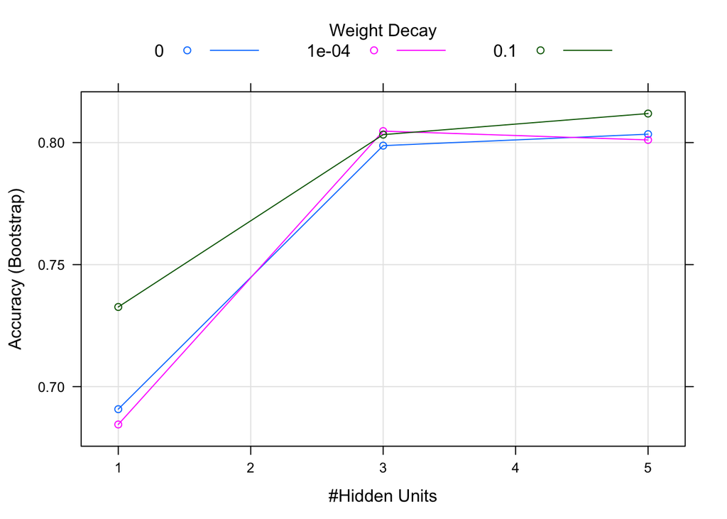

```r
plot(nnet.model)
```

```r
res2 = predict(nnet.model, newdata = test.titanic)
```

```r
# making vectors as a "work-around"
sex <- train.titanic$Sex
pclass <- train.titanic$Pclass
fare <- train.titanic$Fare
age <- train.titanic$Age
survived <- train.titanic$Survived
```

```r
vectors <- cbind(sex,pclass,fare,age,survived)
vectors <- as.data.frame(vectors)
vectors$sex <- factor(vectors$sex)
vectors$pclass <- factor(vectors$pclass)
vectors$survived <- factor(vectors$survived)

head(vectors)
```

```
##   sex pclass    fare age survived
## 1   2      3  7.2500  22        1
## 2   1      1 71.2833  38        2
## 3   1      3  7.9250  26        2
## 4   1      1 53.1000  35        2
## 5   2      3  8.0500  35        1
## 6   2      3  8.4583   0        1
```

```r
sex.test <- test.titanic$Sex
pclass.test <- test.titanic$Pclass
fare.test <- test.titanic$Fare
age.test <- test.titanic$Age
survived.test <- test.titanic$Survived
```

```r
vectors.test <- cbind(sex.test,pclass.test,fare.test,age.test)
vectors.test <- as.data.frame(vectors.test)
colnames(vectors.test) <- c("sex","pclass","fare","age")

head(vectors.test)
```

```
##   sex pclass    fare  age
## 1   2      3  7.8292 34.5
## 2   1      3  7.0000 47.0
## 3   2      2  9.6875 62.0
## 4   2      3  8.6625 27.0
## 5   1      3 12.2875 22.0
## 6   2      3  9.2250 14.0
```

```r
set.seed(1911)
datas1 <- vectors[sample(1:nrow(vectors), 418), ]

vectors.test$sex.test <- factor(vectors.test$sex)
vectors.test$pclass.test <- factor(vectors.test$pclass)
vectors.test$survived.test<- factor(datas1$survived)
```

### Comparing a few more neural networks

```r
net3 <- nnet(survived ~ sex + pclass + fare + age, data = train.titanic,size = 2, linout = FALSE, maxit = 10000)
net4 <- nnet(survived ~ Embarked + pclass + fare + age, data = train.titanic,size = 2, linout = FALSE, maxit = 10000)
net5 <- nnet(survived ~ SibSp + pclass + fare + age, data = train.titanic,size = 2, linout = FALSE, maxit = 10000)
#x <-factor(train_survived$Survived)
#y <-factor(pred_train)
#confusionMatrix(x, y)
```

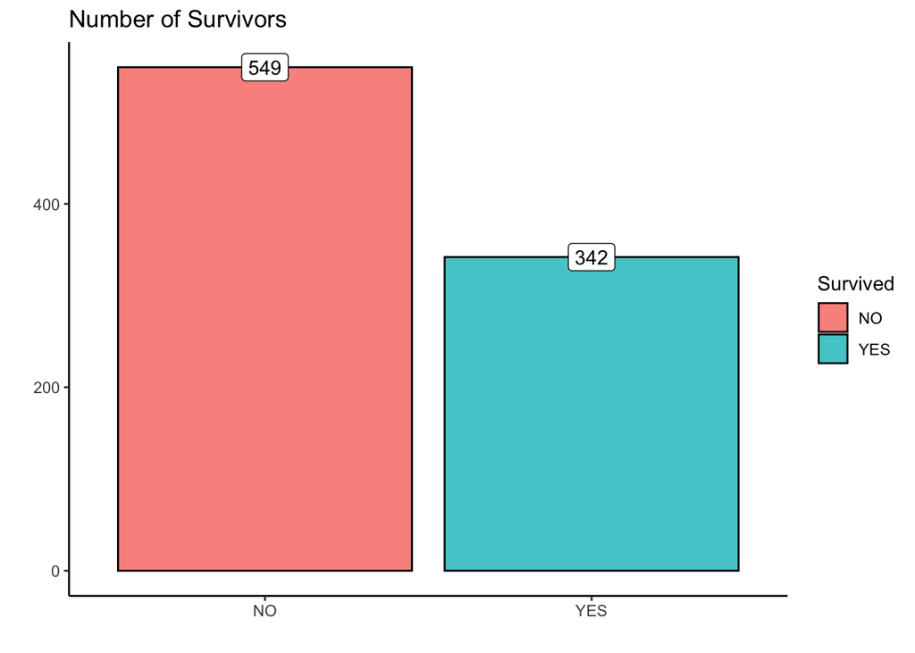

```r
library(ggplot2)
ggplot(TitanicTrain, aes(x = Survived)) +
    geom_bar(stat = "count", aes(fill = Survived), col = "black", alpha = 0.8) +
    labs(x = "", y = "", title = "Number of Survivors") +
    geom_label(stat = "count", aes(label = ..count..)) +
    theme_classic()
```

### Conclusion

##### The neural network **nnet.fit** achieved an acuracy of 71.8%. Though, with more time and tweaking, I believe the model could have improved a bit, a nueral network may not be the best model to use. A number of projects I read were able to achieve higher degrees of accuracy using Random forest models. The number of survivors was 342 while the deceased were almost double at 549.